# Machine Learning in Public Health

Lecture 5: CV and Boostrap

Dr. Yang Feng

# Today’s agenda

- Cross-Validation
- Bootstrap

# Resampling Methods

- Resampling methods: repeatedly draw samples from a training set and refit a model of interest (or compute certain estimates) on each sample in order to obtain additional information about the fitted model (or those estimates)
- Common resampling methods include: cross-validation and bootstrap

# Cross-validation (CV)

- Cross-validation (CV) can be used to estimate the test error associated with a given statistical learning method
  - to evaluate its performance (model assessment)
  - or to select the best model (model selection)
- When to use CV to estimate test error?
  - when you don’t have a designated test set
- CV can be used for both classification and regression
- CV has a few variants; we only discuss the canonical version
- A precursor of CV is the validation set approach

# The validation set approach

- Validation set approach: randomly divide the available set of observations into two parts, a training set and a validation set or hold-out set. The model is fit on the training set, and the fitted model is used to predict the responses for the observations in the validation set.

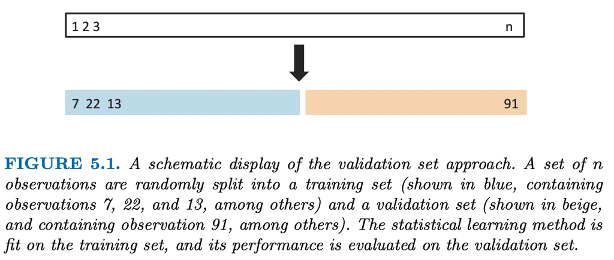

# Drawbacks of the validation set approach

- the validation estimate of the test error rate can be highly variable
- only about a half of the observations are used to train the model (inefficient use of data).
- Cross-validation: a refinement of the validation set approach that addresses these two issues.

# Leave-One-Out Cross-Validation (LOOCV)

- Suppose the training data contains $\{(x_1, y_1), \cdots, (x_n, y_n)\}$
- First, use $n - 1$ observations $\{(x_2, y_2), \cdots, (x_n, y_n)\}$ to train and use the remaining observation $(x_1, y_1)$ to evaluate the performance: $MSE_1 = (y_1 - \hat y_1)^2$
- Repeat this procedure by using $(x_2, y_2)$ as the validation data, training on the $n - 1$ observations $(x_1, y_1), (x_3, y_3), \cdots (x_n, y_n)$, and compute $MSE_2 = (y_2 - \hat y_2)^2$
- Repeat this approach in total $n$ times, which produces $n$ squared errors $MSE_1, \cdots, MSE_n$
- The LOOCV estimate for the test $MSE$ is the average of these $n$ estimates:
  $$CV_{(n)} = \frac{1}{n}\sum_{i=1}^n MSE_i\,.$$
- There is no need to randomly shuffle the training data before implementing LOOCV. Why?

# LOOCV

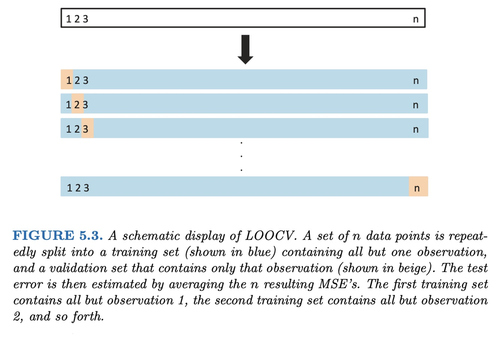

# Potential problems for LOOCV

- Computationally, LOOCV has the potential to be expensive to implement, since the model has to be fit $n$ times
  - However, with least squares linear or polynomial regression, the following formula holds:
    $$CV_{(n)} = \frac{1}{n}\sum_{i=1}^n \left(\frac{y_i - \hat y_i}{1 - h_i}\right)^2\,,$$
  - where $h_i = {{\bf x}_i}^T(X^TX)^{-1}{\bf x_i}$ is the leverage of the $i$th observation.
- The $n$ fitted models are each trained on an almost identical set of observations, and so averaging does not reduce variance much
  - Think about letting $X_i \sim N(0, 1)$ but insist $X_1 = \cdots = X_n$
  - What is the variance of $\bar X$?

# $k$-fold CV

- $k$-fold CV: randomly divide the set of observations into $k$ groups, or folds, of approximately equal size.
- The first fold is treated as a validation set, and the method is fit on the remaining $k-1$ folds. The mean squared error, $MSE_1$, is then computed on the observations in the held-out fold.
- This procedure is repeated $k$ times; each time, a different group of observations is treated as a validation set.
- This process results in $k$ estimates of the test error, $MSE_1, MSE_2, \cdots, MSE_k$.
- The $k$-fold CV estimate is computed by averaging these values,
  $$CV_{(k)} = \frac{1}{k}\sum_{i=1}^k MSE_i.$$
- We commonly use $CV_{(k)}$ to estimate the test error (model evaluation).

# 5-fold CV

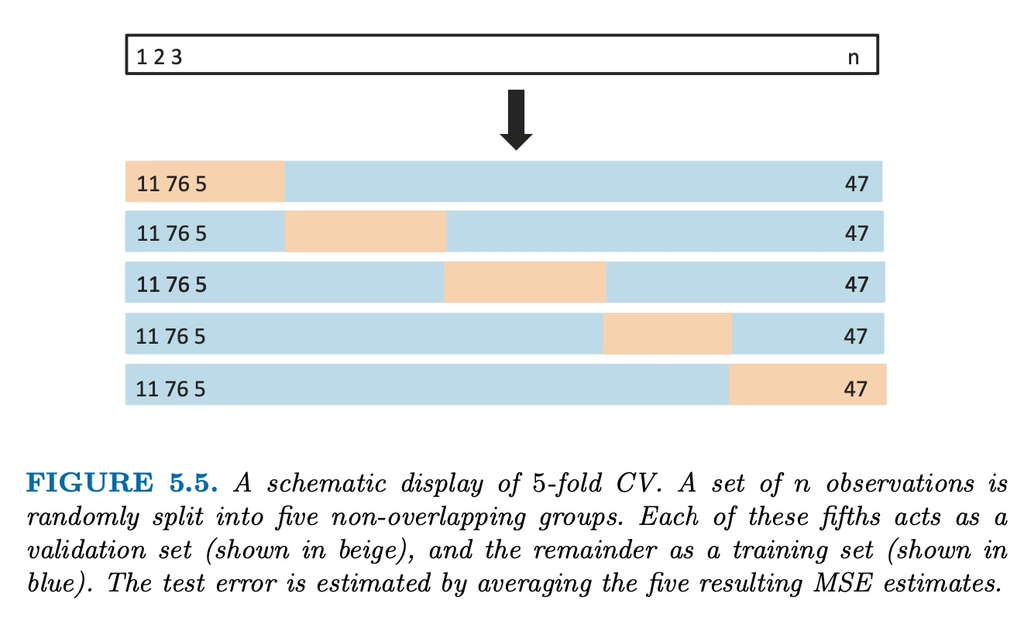

- LOOCV is a special case of $k$-fold CV in which $k=n$

# Bias-variance trade-off for $k$-fold CV

# $k$-fold CV for model selection

# Use $k$-fold CV for classification

- The basic idea of CV for classification is the same as that for regression, except the way to calculate $CV_{(k)}$
  - For example, the LOOCV error rate is
    $$CV_{(n)} = \frac{1}{n}\sum_{i=1}^n Err_i\,,$$
  - where $Err_i = I(y_i \neq \hat y_i)$

# Bootstrap

[figure not shown]

# Bootstrap in Statistics

- Bootstrap: in statistics, bootstrap is any procedure that relies on random sampling with replacement (from the original sample)
- Bootstrap allows assigning **measures of accuracy** (defined in terms of standard error, variance, confidence intervals, prediction error or some other such measure) to *sample estimates*.
- This is a rather strange idea when we first look at it

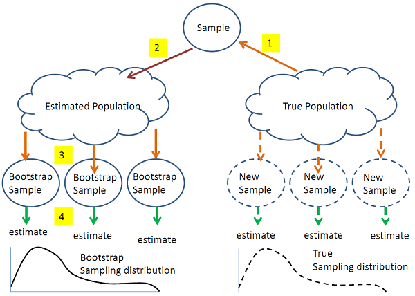

# Importance of Bootstrap

- On the other hand, it is one of the most influential ideas in Statistics invented in the the second half of the 20th century
- As a verb, bootstrap means “get oneself out of a situation using existing resources (without extra help)” (quote: pull oneself over a fence by one’s bootstraps)
- Bootstrap is computationally heavy
- It is a class of widely used procedures. But its theory is beyond this class.
- Bootstrap has different versions (e.g., moving block bootstrap for time series data); we only discuss the simplest kind
- We illustrate the basic bootstrap idea with two toy examples

# What is “sample with replacement” (the first example)?

- Suppose there is a box that contains a black ball and a red ball
- Draw one ball from the box, put it back, and then draw another ball from the box; repeat this process multiple times (see different outcomes?)

  ```r
  set.seed(1)
  sample(c("red","black"), size = 2, replace = TRUE)
  ```

  ```
  ## [1] "red"   "black"
  ```

  ```r
  sample(c("red","black"), size = 2, replace = TRUE)
  ```

  ```
  ## [1] "red" "red"
  ```

  ```r
  sample(c("red","black"), size = 2, replace = TRUE)
  ```

  ```
  ## [1] "black" "red"
  ```

- When we do sample with replacement, it is possible to get one element twice
- What if we sample two elements without replacement from the above box?

# Estimating the distribution of sample mean using a single sample

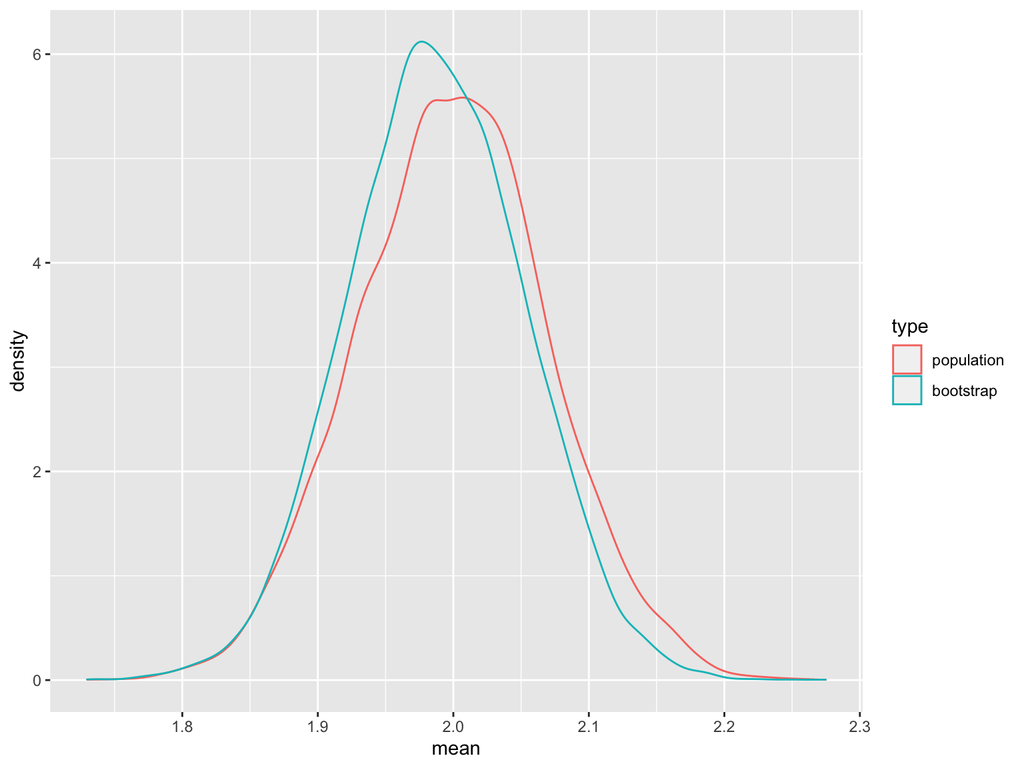

# Next Class

Linear Model Selection and Regularization

- Subset selection
- Ridge regression
- Lasso